# InvestorRiskTolerance_RA2112704010015

## Investor Risk Tolerance and Robo advisors

For this case study the data used is from survey of Consumer Finances which is conducted by the Federal Reserve Board. The data source is : https://www.federalreserve.gov/econres/scf_2009p.htm

```python
import numpy as np
import pandas as pd
import pandas_datareader.data as web
import matplotlib.pyplot as plt
from pandas.plotting import scatter_matrix
import seaborn as sns
import copy
from sklearn.preprocessing import StandardScaler

from sklearn.model_selection import train_test_split
from sklearn.model_selection import KFold
from sklearn.model_selection import cross_val_score
from sklearn.model_selection import GridSearchCV

from sklearn.linear_model import LinearRegression
from sklearn.linear_model import Lasso
from sklearn.linear_model import ElasticNet
from sklearn.tree import DecisionTreeRegressor
from sklearn.neighbors import KNeighborsRegressor
from sklearn.svm import SVR
from sklearn.ensemble import RandomForestRegressor
from sklearn.ensemble import GradientBoostingRegressor
from sklearn.ensemble import ExtraTreesRegressor
from sklearn.ensemble import AdaBoostRegressor

#Libraries for Saving the Model
from pickle import dump
from pickle import load
```

```python
# load dataset
dataset = pd.read_excel('/content/SCFP2009panel.xlsx')
```

```python
#Diable the warnings
import warnings
warnings.filterwarnings('ignore')
```

```python
type(dataset)
```

```
pandas.core.frame.DataFrame
def __init__(data=None, index: Axes | None=None, columns: Axes | None=None, dtype: Dtype | None=None, copy: bool | None=None) -> None
```

[output not shown]

[output cut: 76 more lines]

[output not shown]

```python
dataset.shape
```

```
(19285, 515)
```

```python
#Average SP500 during 2007 and 2009
Average_SP500_2007=1478
Average_SP500_2009=948

#Risk Tolerance 2007
dataset['RiskFree07']= dataset['LIQ07'] + dataset['CDS07'] + dataset['SAVBND07'] + dataset['CASHLI07']
dataset['Risky07'] = dataset['NMMF07'] + dataset['STOCKS07'] + dataset['BOND07']
dataset['RT07'] = dataset['Risky07']/(dataset['Risky07']+dataset['RiskFree07'])

#Risk Tolerance 2009
dataset['RiskFree09']= dataset['LIQ09'] + dataset['CDS09'] + dataset['SAVBND09'] + dataset['CASHLI09']
dataset['Risky09'] = dataset['NMMF09'] + dataset['STOCKS09'] + dataset['BOND09']
dataset['RT09'] = dataset['Risky09']/(dataset['Risky09']+dataset['RiskFree09'])*\
                (Average_SP500_2009/Average_SP500_2007)
```

```python
dataset2 = copy.deepcopy(dataset)
dataset.head()
```

|  | YY1 | Y1 | WGT09 | AGE07 | AGECL07 | EDUC07 | EDCL07 | MARRIED07 | KIDS07 | LIFECL07 | ... | TRANSFOTHINCPCT | PSAVINGPCT | LEVERAGEPCT | I | RiskFree07 | Risky07 | RT07 | RiskFree09 | Risky09 | RT09 |
| --- | --- | --- | --- | --- | --- | --- | --- | --- | --- | --- | --- | --- | --- | --- | --- | --- | --- | --- | --- | --- | --- |
| 0 | 1 | 11 | 11668.134198 | 47 | 3 | 12 | 2 | 1 | 0 | 2 | ... | 0.0 | 93.125197 | 270.403054 | 57 | 7994.813847 | 0.0 | 0.0 | 16000 | 17000 | 0.330422 |
| 1 | 1 | 12 | 11823.456494 | 47 | 3 | 12 | 2 | 1 | 0 | 2 | ... | 0.0 | 93.125197 | 249.593620 | 57 | 7994.813847 | 0.0 | 0.0 | 19000 | 18000 | 0.312036 |
| 2 | 1 | 13 | 11913.228354 | 47 | 3 | 12 | 2 | 1 | 0 | 2 | ... | 0.0 | 93.125197 | 209.233358 | 57 | 7984.457871 | 0.0 | 0.0 | 13000 | 12000 | 0.307876 |
| 3 | 1 | 14 | 11929.394266 | 47 | 3 | 12 | 2 | 1 | 0 | 2 | ... | 0.0 | 93.125197 | 209.273158 | 57 | 7984.457871 | 0.0 | 0.0 | 25000 | 13000 | 0.219429 |
| 4 | 1 | 15 | 11917.722907 | 47 | 3 | 12 | 2 | 1 | 0 | 2 | ... | 0.0 | 93.125197 | 232.690767 | 57 | 7994.813847 | 0.0 | 0.0 | 17000 | 12000 | 0.265410 |

5 rows × 521 columns

Let us compute the percentage change in risk tolerance between 2007 and 2009.

```python
dataset2['PercentageChange'] = np.abs(dataset2['RT09']/dataset2['RT07']-1)
```

Checking for the rows with null or nan values and removing them.

```python
#Checking for any null values and removing the null values'''
print('Null Values =',dataset2.isnull().values.any())
```

```
Null Values = True
```

```python
# Drop the rows containing NA
dataset2=dataset2.dropna(axis=0)

# Remove rows with NaN, inf, or -inf values
dataset2 = dataset2[~dataset2.isin([np.nan, np.inf, -np.inf]).any(axis=1)]

#Checking for any null values and removing the null values
print('Null Values =',dataset2.isnull().values.any())
```

```
Null Values = False
```

Let us plot the risk tolerance of 2007 and 2009.

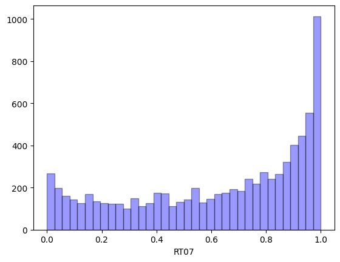

```python
sns.distplot(dataset2['RT07'], hist=True, kde=False,
             bins=int(180/5), color = 'blue',
             hist_kws={'edgecolor':'black'})
```

Looking at the risk tolerance of 2007, we see that a significant number of individuals had risk tolerance close to one.Meaning the investment ws more skewed towards the risky assets as compared to the riskless assets. Now let us look at the risk tolerance of 2009.

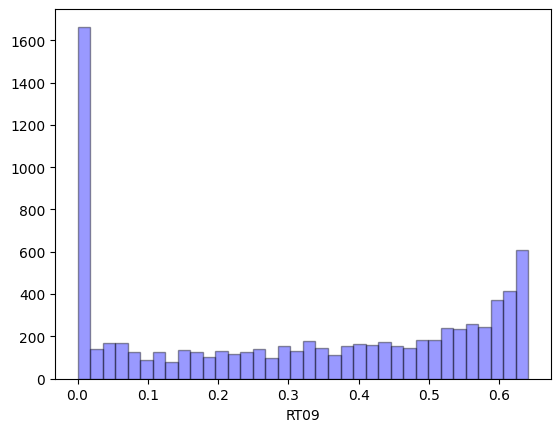

```python
sns.distplot(dataset2['RT09'], hist=True, kde=False,
             bins=int(180/5), color = 'blue',
             hist_kws={'edgecolor':'black'})
```

```python
dataset3 = copy.deepcopy(dataset2)
```

```python
dataset3 = dataset3[dataset3['PercentageChange']<=.1]
```

```python
dataset3['TrueRiskTolerance'] = (dataset3['RT07'] + dataset3['RT09'])/2
```

Let us drop other labels which might not be needed for the prediction.

```python
dataset3.drop(labels=['RT07', 'RT09'], axis=1, inplace=True)
dataset3.drop(labels=['PercentageChange'], axis=1, inplace=True)
```

## 3.2. Feature Selection-Limit the Feature Space

### 3.2.2. Features elimination

In order to filter the features further we do the following:

1. Checking the description in the Data Dictionary (https://www.federalreserve.gov/econres/files/codebk2009p.txt, https://www.federalreserve.gov/econresdata/scf/files/fedstables.macro.txt)and only keep the features that are intuitive

The description is as follows:

```python
keep_list2 = ['AGE07','EDCL07','MARRIED07','KIDS07','OCCAT107','INCOME07','RISK07','NETWORTH07','TrueRiskTolerance']

drop_list2 = [col for col in dataset3.columns if col not in keep_list2]

dataset3.drop(labels=drop_list2, axis=1, inplace=True)
```

Let us look at the correlation among the features.

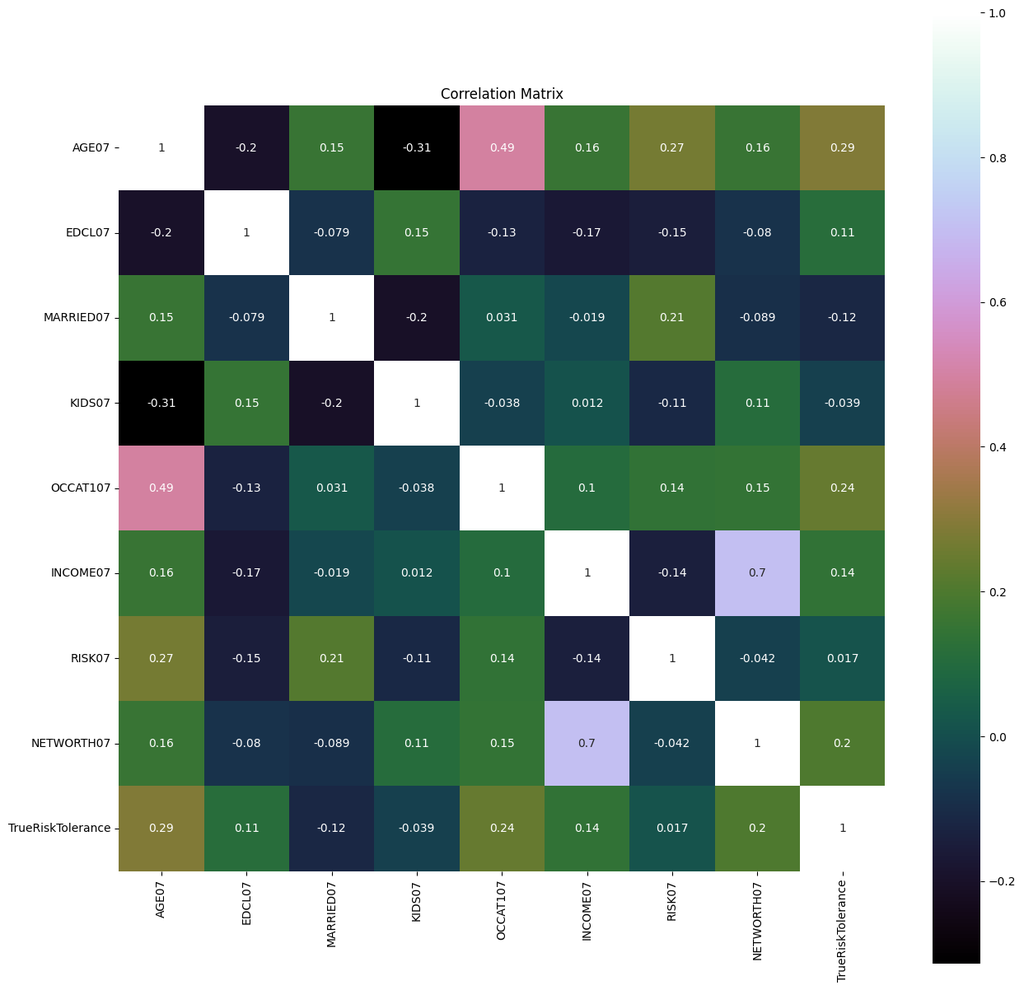

```python
# correlation
correlation = dataset3.corr()
plt.figure(figsize=(15,15))
plt.title('Correlation Matrix')
sns.heatmap(correlation, vmax=1, square=True,annot=True,cmap='cubehelix')
```

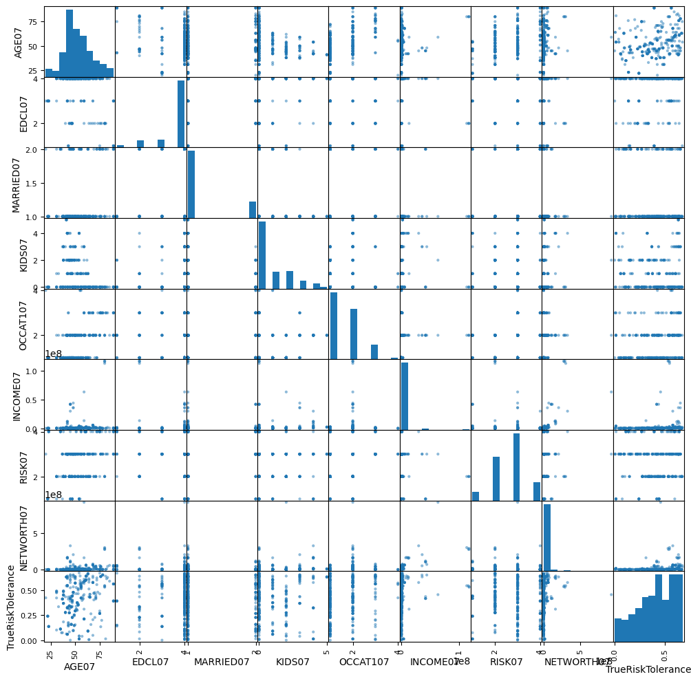

```python
# Scatterplot Matrix
from pandas.plotting import scatter_matrix
plt.figure(figsize=(15,15))
scatter_matrix(dataset3,figsize=(12,12))
plt.show()
```

As per the paper "Does Risk Tolerance Decrease With Age?(Hui Wang1,Sherman Hanna)", Relative risk aversion decreases as people age (i.e., the proportion of net wealth invested in risky assets increases as people age) when other variables are held constant.Therefore, risk tolerance increases with age.

So, in summary all the variables and their relationship with risk tolerance seems intuitive.

# 4. Evaluate Algorithms and Models

Performing a train and test split in this step.

```python
# split out validation dataset for the end
Y= dataset3["TrueRiskTolerance"]
X = dataset3.loc[:, dataset3.columns != 'TrueRiskTolerance']
# scaler = StandardScaler().fit(X)
# rescaledX = scaler.transform(X)
validation_size = 0.2
seed = 3
X_train, X_validation, Y_train, Y_validation = train_test_split(X, Y, test_size=validation_size, random_state=seed)
```

## 4.2. Test Options and Evaluation Metrics

```python
# test options for regression
num_folds = 10
scoring = 'r2'
```

### Regression Models

```python
# spot check the algorithms
models = []
models.append(('LR', LinearRegression()))
models.append(('LASSO', Lasso()))
models.append(('EN', ElasticNet()))
models.append(('KNN', KNeighborsRegressor()))
models.append(('CART', DecisionTreeRegressor()))
models.append(('SVR', SVR()))
#Neural Network
#models.append(('MLP', MLPRegressor()))
#Ensable Models
# Boosting methods
models.append(('ABR', AdaBoostRegressor()))
models.append(('GBR', GradientBoostingRegressor()))
# Bagging methods
models.append(('RFR', RandomForestRegressor()))
models.append(('ETR', ExtraTreesRegressor()))
```

### K-folds cross validation

```python
results = []
names = []
for name, model in models:
    kfold = KFold(n_splits=num_folds,shuffle=True,random_state=seed)
    #converted mean square error to positive. The lower the beter
    cv_results = -1* cross_val_score(model, X_train, Y_train, cv=kfold, scoring=scoring)
    results.append(cv_results)
    names.append(name)
    msg = "%s: %f (%f)" % (name, cv_results.mean(), cv_results.std())
    print(msg)
```

```
LR: -0.102704 (0.179297)
LASSO: -0.041555 (0.109033)
EN: -0.047729 (0.108990)
KNN: -0.424599 (0.141428)
CART: -0.543682 (0.206065)
SVR: -0.127821 (0.100887)
ABR: -0.374642 (0.135225)
GBR: -0.617709 (0.140568)
RFR: -0.717485 (0.106484)
ETR: -0.700180 (0.142513)
```

### Algorithm comparison

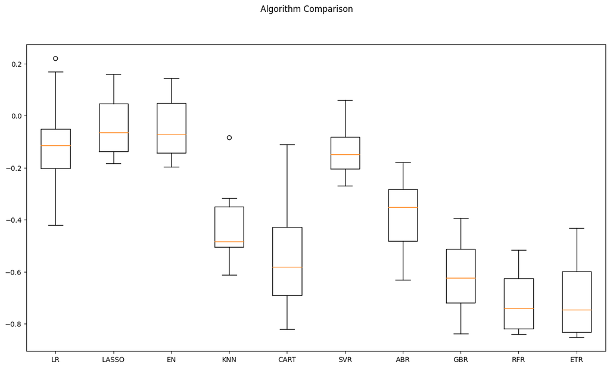

```python
# compare algorithms
fig = plt.figure()
fig.suptitle('Algorithm Comparison')
ax = fig.add_subplot(111)
plt.boxplot(results)
ax.set_xticklabels(names)
fig.set_size_inches(15,8)
plt.show()
```

The non linear models perform better than the linear models, which means that a non linear relationship between the risk tolerance and the difference variables use to predict it. Given random forest regression is one of the best methods, we use it for further grid search.

# 5. Model Tuning and Grid Search

Given that the Random Forest is the best model, Grid Search is performed on Random Forest.

```python
# 8. Grid search : RandomForestRegressor
'''
n_estimators : integer, optional (default=10)
    The number of trees in the forest.
'''
param_grid = {'n_estimators': [50,100,150,200,250,300,350,400]}
model = RandomForestRegressor()
kfold = KFold(n_splits=num_folds,shuffle=True,random_state=seed)
grid = GridSearchCV(estimator=model, param_grid=param_grid, scoring=scoring, cv=kfold)
grid_result = grid.fit(X_train, Y_train)
print("Best: %f using %s" % (grid_result.best_score_, grid_result.best_params_))
means = grid_result.cv_results_['mean_test_score']
stds = grid_result.cv_results_['std_test_score']
params = grid_result.cv_results_['params']
for mean, stdev, param in zip(means, stds, params):
    print("%f (%f) with: %r" % (mean, stdev, param))
```

```
Best: 0.717498 using {'n_estimators': 50}
0.717498 (0.098438) with: {'n_estimators': 50}
0.712798 (0.109874) with: {'n_estimators': 100}
0.715560 (0.098809) with: {'n_estimators': 150}
0.703949 (0.112696) with: {'n_estimators': 200}
0.712560 (0.101175) with: {'n_estimators': 250}
0.704628 (0.104184) with: {'n_estimators': 300}
0.715575 (0.103407) with: {'n_estimators': 350}
0.706318 (0.108096) with: {'n_estimators': 400}
```

# 6. Finalise the Model

```python
# prepare model
model = RandomForestRegressor(n_estimators = 250)
model.fit(X_train, Y_train)
```

```
RandomForestRegressor(n_estimators=250)
```

```python
from sklearn.metrics import r2_score
predictions_train = model.predict(X_train)
print(r2_score(Y_train, predictions_train))
```

```
0.9635909609702344
```

```python
# estimate accuracy on validation set
# transform the validation dataset
from sklearn.metrics import mean_squared_error
from sklearn.metrics import r2_score
#rescaledValidationX = scaler.transform(X_validation)
predictions = model.predict(X_validation)
print(mean_squared_error(Y_validation, predictions))
print(r2_score(Y_validation, predictions))
```

```
0.007786513555598137
0.7613062151188495
```

From the mean square error and R2 shown above for the test set, the results look good.

## 6.2. Feature Importance and Features Intuition

Looking at the details above Random forest be worthy of further study. Let us look into the Feature Importance of the RF model

```
[0.21961171 0.02598212 0.01482337 0.04361485 0.02569335 0.2516477
 0.04825565 0.37037126]
```

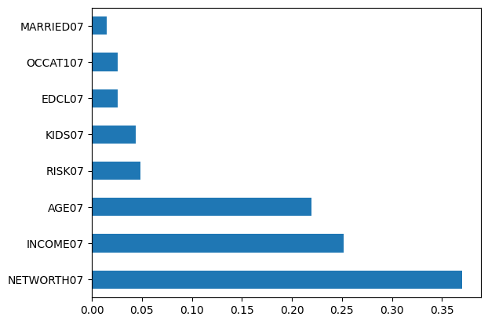

```python
import pandas as pd
import numpy as np
model = RandomForestRegressor(n_estimators= 200,n_jobs=-1)
model.fit(X_train,Y_train)
print(model.feature_importances_) #use inbuilt class feature_importances of tree based classifiers
#plot graph of feature importances for better visualization
feat_importances = pd.Series(model.feature_importances_, index=X.columns)
feat_importances.nlargest(10).plot(kind='barh')
plt.show()
```

From the chart above, income and networth followed by age and willingness to take risk are the key variables to decide the risk tolerance. These variables have been considered as the key variables to model the risk tolerance across several literature.

## 6.3. Save Model for Later Use

```python
# Save Model Using Pickle
from pickle import dump
from pickle import load

# save the model to disk
filename = 'finalized_model.sav'
dump(model, open(filename, 'wb'))
```

```python
# load the model from disk
loaded_model = load(open(filename, 'rb'))
# estimate accuracy on validation set
predictions = loaded_model.predict(X_validation)
result = mean_squared_error(Y_validation, predictions)
print(r2_score(Y_validation, predictions))
print(result)
```

```
0.7648446536383153
0.007671084913368556
```